# Statistical Rethinking Chapter 14 End of Chapter Questions

# Easy Questions

## 14E1

> Add to the following model varying slopes on the predictor **x**
> $$\begin{align}
> y_i &\sim \text{Normal}(\mu_i, \sigma) \\
> \mu_i &= \alpha_{\text{GROUP[i]}} + \beta x_i \\
> \alpha_{\text{GROUP[i]}} &\sim \text{Normal}(\alpha, \sigma_\alpha) \\
> \alpha &\sim \text{Normal}(0, 10) \\
> \beta &\sim \text{Normal}(0, 1) \\
> \sigma &\sim \text{Exponential}(1) \\
> \sigma_\alpha &\sim \text{Exponential}(1)
> \end{align}$$

To add varying slopes, $\beta$ will differ by GROUP. And then we will need to add the covariance matrix for $\alpha$ and $\beta$.

$$\begin{align}
y_i &\sim \text{Normal}(\mu_i, \sigma) \\
\mu_i &= \alpha_{\text{GROUP[i]}} + \beta_{\text{GROUP[i]}} x_i \\
\begin{bmatrix}
\alpha_{\text{GROUP[i]}} \\ \beta_{\text{GROUP[i]}}
\end{bmatrix} &\sim \text{MVNormal} \left(
\begin{bmatrix}
\alpha \\ \beta
\end{bmatrix}
, S \right) & \text{[S is the covariance matrix]} \\
S &= \begin{pmatrix}
\sigma_\alpha & 0 \\
0 & \sigma_\beta
\end{pmatrix}
R
\begin{pmatrix}
\sigma_\alpha & 0 \\
0 & \sigma_\beta
\end{pmatrix}
\\
\alpha &\sim \text{Normal}(0, 10) \\
\beta &\sim \text{Normal}(0, 1) \\
\sigma &\sim \text{Exponential}(1) \\
\sigma_\alpha &\sim \text{Exponential}(1) \\
\sigma_\beta &\sim \text{Exponential}(1) \\
R &\sim \text{LKJcorr}(2)
\end{align}$$

We have a 2D Gaussian distribution defining $\alpha$ and $\beta$ priors. S is the covariance matrix and R is the correlation matrix between the two parameters.

## 14E2

> Think up a context in which varying intercepts will be positively correlated with varying slopes. Provide a mechanistic explanation for the correlation.

A positive correlation implies that as the intercept increases so does the slope. One example could be where we try to model the wages earned with number of hours worked as predictors. Different jobs form a natural cluster here, with high paying jobs having both a higher intercept as well a higher slope (hourly wage rate).

## 14E3

> When is it possible for a varying slopes model to have fewer effective parameters (as estimated by WAIC or PSIS) than the corresponding model with fixed (unpooled) slopes? Explain.

As we saw in the previous chapter as well, when the standard deviation on the varying effect is small, then the effective number of parameters tend to be less than the the actual parameters. Possibly if there is high correlation between the intercepts and slopes (in a varying intercepts + varying slopes model), then the effective number of parameters could be less in the pooled model, since we get less information from the two correlated intercept + slope.

# Medium Questions

## 14M1

> Repeat the café robot simulation from the beginning of the chapter. This time, set rho to zero, so that there is no correlation between intercepts and slopes. How does the posterior distribution of the correlation reflect this change in the underlying simulation?

Let’s redo the simulation. We first define the parameters:

```r
a <- 3.5       # average morning wait time
b <- (-1)      # average difference afternoon wait time
sigma_a <- 1   # std dev in intercepts
sigma_b <- 0.5 # std dev in slopes
rho <- (0)     # correlation between intercepts and slopes
```

We next build the 2D Gaussian Distribution:

```r
# mean
Mu <- c(a, b)

# Build the covariance matrix
sigmas <- c(sigma_a, sigma_b) # std devs
Rho <- matrix(c(1, rho, rho, 1), nrow = 2) # correlation matrix

# now matrix multiply to get covariance matrix
Sigma <- diag(sigmas) %*% Rho %*% diag(sigmas)
```

Next we do the simulation:

```r
N_cafes <- 20

# simulate alpha and betas
set.seed(1)
vary_effects <- MASS::mvrnorm(N_cafes, Mu, Sigma)
a_cafe <- vary_effects[,1]
b_cafe <- vary_effects[,2]

set.seed(22)
N_visits <- 10
afternoon <- rep(0:1, N_visits * N_cafes/2)
cafe_id <- rep(1:N_cafes, each = N_visits)
mu <- a_cafe[cafe_id] + b_cafe[cafe_id] * afternoon
sigma <- 0.5        # std dev within cafes
wait <- rnorm(N_visits * N_cafes, mu, sigma)
d <- data.frame(cafe = cafe_id, afternoon = afternoon, wait = wait)
```

Next we build the model:

```r
library(rethinking)
set.seed(123)
m1 <- ulam(
    alist(
        wait ~ normal(mu, sigma),
        mu <- a_cafe[cafe] + b_cafe[cafe]*afternoon,
        c(a_cafe, b_cafe)[cafe] ~ multi_normal(c(a,b), Rho, sigma_cafe),
        a ~ normal(5, 2),
        b ~ normal(-1, 0.5),
        sigma_cafe ~ exponential(1),
        sigma ~ exponential(1),
        Rho ~ lkj_corr(2)
    ), data = d, chains = 4, cores = 4
)
```

Let’s plot the posterior correlation between slopes and intercepts:

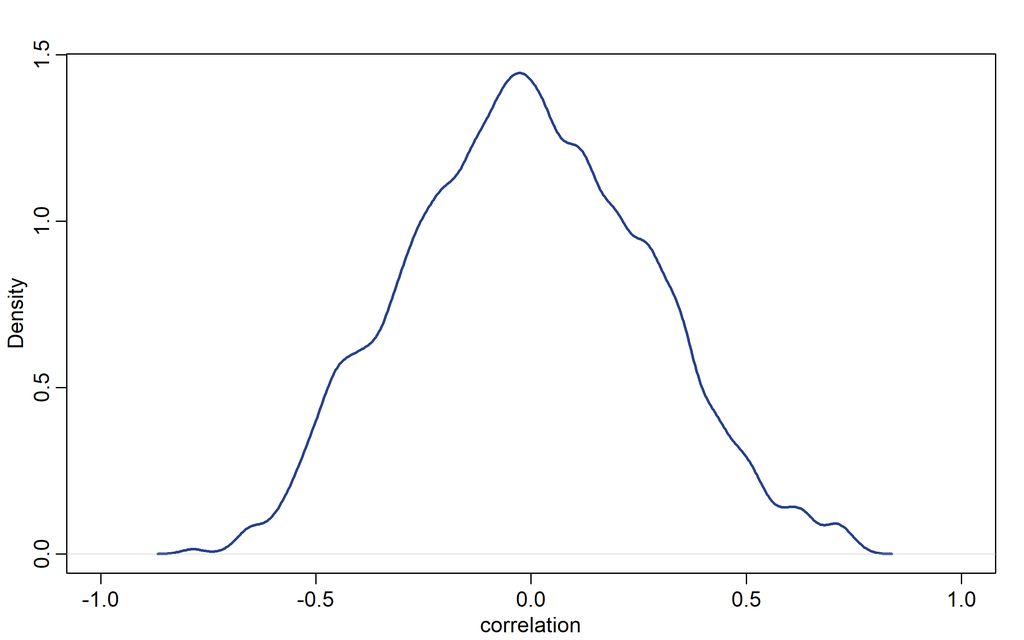

```r
post <- extract.samples(m1)
dens(post$Rho[,1,2], xlim = c(-1, 1),
     col = 'royalblue4', lwd = 2, xlab = "correlation")  # posterior
```

The posterior is centred around zero, but the credible interval have posterior mass ranging from -0.5 to +0.5, although we only simulated 20 observations, so there’s bound to be high variation in our estimates. But, overall the model does capture the zero correlation correctly.

## 14M2

> Fit this multilevel model to the simulated café data:
> $$\begin{align}
> W_i &\sim \text{Normal}(\mu_i, \sigma) \\
> \mu_i &= \alpha_{ \text{CAFÉ[i]} } + \beta_{CAFÉ[i]}A_i \\
> \alpha_{ \text{CAFÉ[i]} } &\sim \text{Normal}(\alpha, \sigma_\alpha) \\
> \beta_{ \text{CAFÉ[i]} } &\sim \text{Normal}(\beta, \sigma_\beta) \\
> \alpha &\sim \text{Normal}(0, 10) \\
> \beta &\sim \text{Normal}(0, 10) \\
> \sigma, \sigma_\alpha, \sigma_\beta &\sim \text{Exponential}(1)
> \end{align}$$

We have a model that has both varying intercepts and varying slopes, but which does not take pool the correlation between them.

First let’s simulate the data from the chapter:

```r
a <- 3.5       # average morning wait time
b <- (-1)      # average difference afternoon wait time
sigma_a <- 1   # std dev in intercepts
sigma_b <- 0.5 # std dev in slopes
rho <- (-0.7)  # correlation between intercepts and slopes
# mean
Mu <- c(a, b)

# Build the covariance matrix
sigmas <- c(sigma_a, sigma_b) # std devs
Rho <- matrix(c(1, rho, rho, 1), nrow = 2) # correlation matrix

# now matrix multiply to get covariance matrix
Sigma <- diag(sigmas) %*% Rho %*% diag(sigmas)

N_cafes <- 20

# simulate alpha and betas
set.seed(1)
vary_effects <- MASS::mvrnorm(N_cafes, Mu, Sigma)
a_cafe <- vary_effects[,1]
b_cafe <- vary_effects[,2]

set.seed(22)
N_visits <- 10
afternoon <- rep(0:1, N_visits * N_cafes/2)
cafe_id <- rep(1:N_cafes, each = N_visits)
mu <- a_cafe[cafe_id] + b_cafe[cafe_id] * afternoon
sigma <- 0.5        # std dev within cafes
wait <- rnorm(N_visits * N_cafes, mu, sigma)
d <- data.frame(cafe = cafe_id, afternoon = afternoon, wait = wait)
```

Modelling it:

```r
# model in question
m2 <- ulam(
    alist(
        wait ~ normal(mu, sigma),
        mu <- a_cafe[cafe] + b_cafe[cafe]*afternoon,
        a_cafe[cafe] ~ normal(a, sigma_a),
        b_cafe[cafe] ~ normal(b, sigma_b),

        a ~ normal(0, 10),
        b ~ normal(0, 10),
        c(sigma, sigma_a, sigma_b) ~ exponential(1)
    ), data = d, chains = 4, cores = 4, log_lik = TRUE
)

# model from the chapter
m14.1 <- ulam(
    alist(
        wait ~ normal(mu, sigma),
        mu <- a_cafe[cafe] + b_cafe[cafe]*afternoon,
        c(a_cafe, b_cafe)[cafe] ~ multi_normal(c(a,b), Rho, sigma_cafe),
        a ~ normal(5, 2),
        b ~ normal(-1, 0.5),
        sigma_cafe ~ exponential(1),
        sigma ~ exponential(1),
        Rho ~ lkj_corr(2)
    ), data = d, chains = 4, cores = 4, log_lik = TRUE
)
```

Comparing the two models using WAIC:

```r
compare(m2, m14.1)
```

```
##           WAIC       SE   dWAIC      dSE    pWAIC     weight
## m14.1 300.4581 17.66751 0.00000       NA 29.65593 0.95030411
## m2    306.3599 17.89595 5.90172 3.636895 30.30681 0.04969589
```

The predictive accuracy is hardly different between the models. The model that models the covariance between them is supposed to do slightly better out of sample, but dSE is high enough that we cannot be sure.

Let’s plot the posterior predictions:

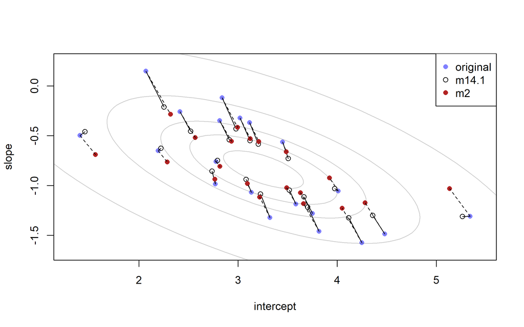

```r
#compute unpooled estimates directly from data
a1 <- sapply(1:N_cafes, function(i) mean(wait[cafe_id == i & afternoon == 0]))
b1 <- sapply(1:N_cafes, function(i) mean(wait[cafe_id == i & afternoon == 1])) - a1

# extract posterior means of partially pooled estimates
post <- extract.samples(m14.1)
a2 <- colMeans(post$a_cafe)
b2 <- colMeans(post$b_cafe)

# extract posterior means of m2
post2 <- extract.samples(m2)
a3 <- colMeans(post2$a_cafe)
b3 <- colMeans(post2$b_cafe)


# plot both and connect with lines

plot(a1, b1, xlab = "intercept", ylab = "slope",
     pch = 16, col = rangi2, ylim = c(min(b1) - 0.1, max(b1) + 0.1),
     xlim = c(min(a1) - 0.1, max(a1) + 0.1))

# plot predictions from m14.1
points(a2, b2, pch = 1)
# connect lines from original to m14.1
for(i in 1:N_cafes)
    lines( c(a1[i], a2[i]), c(b1[i], b2[i]) )


# connect lines from original to m2
points(a3, b3, pch = 16, col = "firebrick")
for(i in 1:N_cafes)
    lines( c(a1[i], a3[i]), c(b1[i], b3[i]), lty = 2)

# superimposing contours of the population

# compute posterior mean bivariate Gaussian
Mu_est <- c(mean(post$a), mean(post$b))
rho_est <- mean(post$Rho[,1,2])
sa_est <- mean(post$sigma_cafe[,1])
sb_est <- mean(post$sigma_cafe[,2])
cov_ab <- sa_est*sb_est*rho_est
Sigma_est <- matrix(c(sa_est^2, cov_ab, cov_ab, sb_est^2), ncol = 2)

# draw contours
library(ellipse)
for(l in c(0.1, 0.3, 0.5, 0.8, 0.99))
    lines(ellipse(Sigma_est, centre = Mu_est, level = l), col = col.alpha('black', 0.2))


legend("topright", legend = c("original", "m14.1", "m2"), pch = c(16, 1, 16), col = c(rangi2, "black", "firebrick"))
```

The models mostly agree for the data points closer to the centre (mean of the multi-variate Gaussian), but the results between the models diverge more and more as we travel farther from the centre. Model `m14.1` that takes the covariance between the slopes and intercepts expects the correlations between them, so for the point on the right, it understands that a high intercept must be associated with a larger negative slope, while `m2`, which does not take the covariance of the parameters into account, or rather assumes that it is zero, does not take this into account and thus applies greater shrinkage and we can see that it shrinks the estimate for the slope much more. We can make a similar observation about the point on the left.

## 14M3

> Re-estimate the varying slopes model for the UCBadmit data, now using a non-centered parameterization. Compare the efficiency of the forms of the model, using n_eff. Which is better? Which chain sampled faster?

There is no model fit to the UCBadmit data in the chapter. Let’s fit one.

```r
library(rethinking)
data("UCBadmit")
d <- UCBadmit
d
```

```
##    dept applicant.gender admit reject applications
## 1     A             male   512    313          825
## 2     A           female    89     19          108
## 3     B             male   353    207          560
## 4     B           female    17      8           25
## 5     C             male   120    205          325
## 6     C           female   202    391          593
## 7     D             male   138    279          417
## 8     D           female   131    244          375
## 9     E             male    53    138          191
## 10    E           female    94    299          393
## 11    F             male    22    351          373
## 12    F           female    24    317          341
```

We will use department as the clustering variable and use gender as the predictor which will have varying slopes.

$$\begin{align}
A_i &\sim \text{Binomial}(N_i, p_i) \\
\text{logit}(p_i) &= \alpha_{\text{dept}} + \beta_{\text{dept}}M \\
\text{The varying effects:} & \\
\begin{bmatrix}
\alpha_{\text{dept}} \\ \beta_{\text{dept}}
\end{bmatrix} &\sim \text{MVNormal}
\left(
\begin{bmatrix}
\alpha \\ \beta
\end{bmatrix}, S
\right) \\
\text{Priors}& \\
S &= \begin{pmatrix} \sigma_\alpha & 0 \\ 0 & \sigma_\beta \end{pmatrix}
R
\begin{pmatrix} \sigma_\alpha & 0 \\ 0 & \sigma_\beta \end{pmatrix} \\
\alpha &\sim \text{Normal}(0, 1.5) \\
\beta &\sim \text{Normal}(0, 0.5) \\
\sigma_\alpha, \sigma_\beta &\sim \text{Exponential}(1) \\
R &\sim \text{LKJcorr}(2)
\end{align}$$

To simplify things, I will use dummy variable approach for gender.

```r
dat_list <- list(
    admit = d$admit,
    N = d$applications,
    M = ifelse(d$applicant.gender == "female", 0L, 1L),
    dept = as.integer(d$dept)
)

m3 <- ulam(
    alist(
        admit ~ dbinom(N, p),
        logit(p) <- a_dept[dept] + b_dept[dept]*M,

        # varying effects 2D Gaussian
        c(a_dept, b_dept)[dept] ~ multi_normal(c(a, b), Rho, sigma),

        a ~ dnorm(0, 1.5),
        b ~ dnorm(0, 0.5),
        sigma ~ dexp(1),
        Rho ~ dlkjcorr(2)
    ), data = dat_list, chains = 4, cores = 4
)
```

Let’s do a posterior validation check similar to what we did in chapter 11:

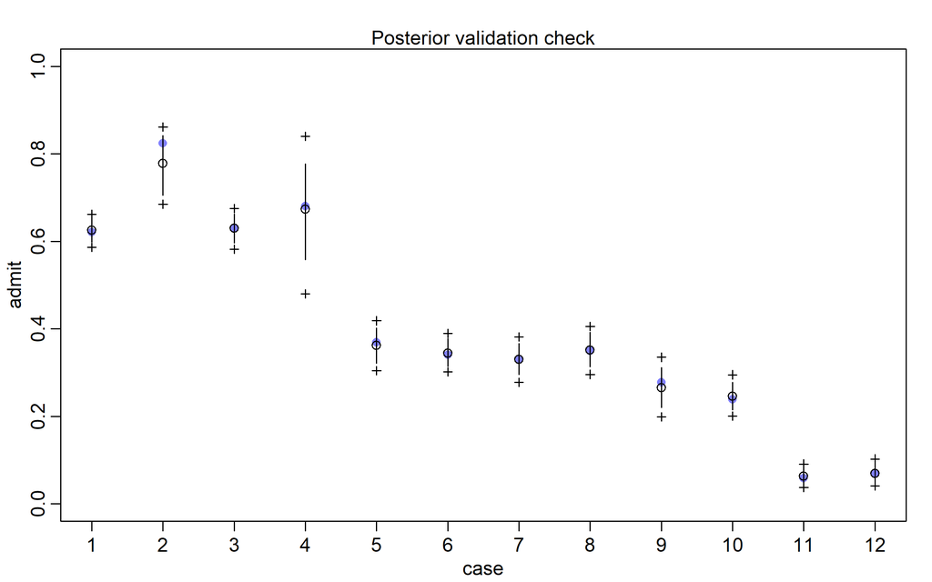

```r
postcheck(m3)
```

The model’s predictions fit the data well

Let’s check the posterior mean:

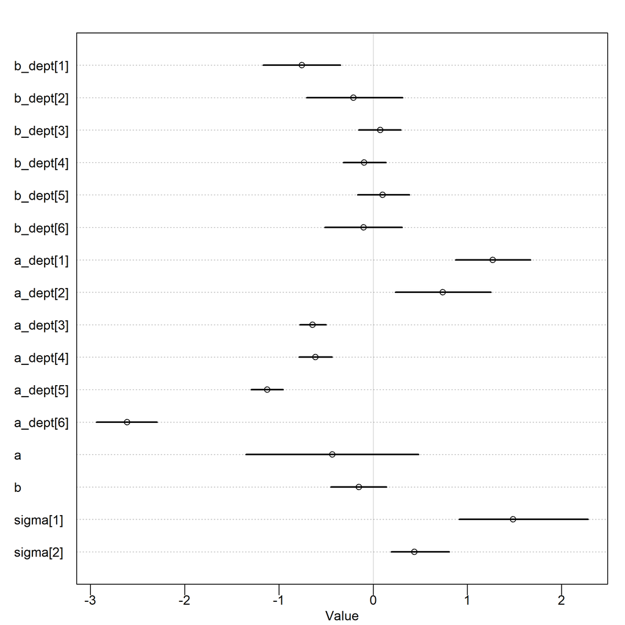

```r
plot(precis(m3, 2))
```

The intercept for average gender effect contains probability mass on either size of zero. This is also the case for the all the varying slopes except for `b_dept[1]`

Now let us create the non-centered version of it:

```r
m3_nc <- ulam(
    alist(
        admit ~ dbinom(N, p),

        # split the a_dept into a_bar + something, similar for b_dept
        logit(p) <- a_bar + beta[dept, 1] + (b_bar + beta[dept, 2])*M,

        a_bar ~ dnorm(0, 1.5),
        b_bar ~ dnorm(0, 0.5),

        # varying effects 2D Gaussian
        transpars> matrix[dept, 2]: beta <- compose_noncentered(sigma_dept, L_Rho_dept, z_dept),
        matrix[2, dept]: z_dept ~ normal(0, 1),

        vector[2]:sigma_dept ~ exponential(1),
        cholesky_factor_corr[2]: L_Rho_dept ~ lkj_corr_cholesky(2),

        gq> matrix[2,2]: Rho <<- Chol_to_Corr(L_Rho_dept)

    ), data = dat_list, chains = 4, cores = 4
)
```

Looking at the posterior:

```r
precis(m3_nc, 2)
```

```
##                     mean        sd       5.5%     94.5%     n_eff     Rhat4
## a_bar         -0.4869221 0.5792904 -1.4059864 0.3875147  524.9241 1.0040697
## b_bar         -0.1422446 0.1810711 -0.4269736 0.1387055 1203.0321 0.9997316
## sigma_dept[1]  1.5035274 0.5032224  0.9285565 2.4010549  619.1730 1.0033110
## sigma_dept[2]  0.4298670 0.2051979  0.1809887 0.7915801  803.0795 1.0003899
```

We get similar results. The `n_eff` is actually worse for the non-centred model. Timing wise, I took note of the total elapsed time displayed for the 4 chains for sampling, and the non-centred version did worse (2 seconds per chain vs 1 second per chain for centered version of the model).

It could be that the parametrisation was not the most efficient one.

## 14M4

> Use WAIC to compare the Gaussian process model of Oceanic tools to the models fit to the same data in Chapter 11. Pay special attention to the effective numbers of parameters, as estimated byWAIC.

Let’s re-create the three models from chapter 11 first:

```r
library(rethinking)
data("Kline")
d <- Kline
d$P <- scale(log(d$population))
d$contact_id <- ifelse(d$contact == "high", 2, 1)

dat <- list(
    T = d$total_tools,
    P = d$P,
    cid = d$contact_id
)

# intercept only
m11.9 <- ulam(
    alist(
        T ~ dpois(lambda),
        log(lambda) <- a,
        a ~ dnorm(3, 0.5)
    ), data = dat, chains = 4, log_lik = TRUE
)

# interaction model
m11.10 <- ulam(
    alist(
        T ~ dpois(lambda),
        log(lambda) <- a[cid] + b[cid] * P,
        a[cid] ~ dnorm(3, 0.5),
        b[cid] ~ dnorm(0, 0.2)
    ), data = dat, chains = 4, log_lik = TRUE
)

dat2 <- list(T = d$total_tools, P = d$population, cid = d$contact_id)
m11.11 <- ulam(
    alist(
        T ~ dpois(lambda),
        lambda <- exp(a[cid]) * P^b[cid] / g,
        a[cid] ~ dnorm(1, 1),
        b[cid] ~ dexp(1),
        g ~ dexp(1)
    ), data = dat2, chains = 4, log_lik = TRUE
)
```

Next, let us re-create the model from this chapter:

```r
# load distance matrix
data("islandsDistMatrix") # matrix of pairwise distances b/w islands in 1000 kms

# display (measured in thousands of km)
Dmat <- islandsDistMatrix
colnames(Dmat) <- c("Ml", "Ti", "SC", "Ya", "Fi", "Tr", "Ch", "Mn", "To", "Ha")

data(Kline2)    # load the ordinary data with coordinates
d <- Kline2
d$society <- 1:10    # index observations

dat_list <- list(
    T = d$total_tools,
    P = d$population,
    society = d$society,
    Dmat = islandsDistMatrix
)


m14.8 <- ulam(
    alist(
        T ~ dpois(lambda),
        lambda <- (a * P^b / g) * exp(k[society]),

        vector[10]:k ~ multi_normal(0, SIGMA),

        matrix[10, 10]:SIGMA <- cov_GPL2(Dmat, etasq, rhosq, 0.01),
        c(a, b, g) ~ dexp(1),
        etasq ~ dexp(2),
        rhosq ~ dexp(0.5)
    ), data = dat_list, chains = 4, cores = 4, iter = 2000, log_lik = TRUE
)
```

Finally, let us compare all the models:

```r
compare(m14.8, m11.9, m11.10, m11.11)
```

```
##             WAIC        SE    dWAIC      dSE    pWAIC       weight
## m14.8   67.35611  2.350044  0.00000       NA 3.983895 9.973981e-01
## m11.11  79.57030 11.200427 12.21419 11.27166 4.591556 2.221213e-03
## m11.10  83.09793 12.080428 15.74182 11.95803 5.852763 3.806929e-04
## m11.9  140.79595 31.891102 73.43984 32.85552 7.661639 1.126183e-16
```

## 14M5

> Modify the phylogenetic distance example to use group size as the outcome and brain size as a predictor. Assuming brain size influences group size, what is your estimate of the effect? How does phylogeny influence the estimate?

```r
library(rethinking)
library(ape)
data("Primates301")     # primates data
data("Primates301_nex") # phylogeny data
d <- Primates301
d$name <- as.character(d$name)
dstan <- d[complete.cases(d$group_size, d$body, d$brain), ]
spp_obs <- dstan$name

dat_list <- list(
    N_spp = nrow(dstan),
    M     = standardize(log(dstan$body)),
    B     = standardize(log(dstan$brain)),
    G     = standardize(log(dstan$group_size)),
    Imat  = diag(nrow(dstan))
)

tree_trimmed <- keep.tip(Primates301_nex, spp_obs)
Dmat <- cophenetic(tree_trimmed)

dat_list$Dmat <- Dmat[spp_obs, spp_obs] / max(Dmat)

m5 <- ulam(
    alist(
        G ~ multi_normal(mu, SIGMA),
        mu <- a + bM*M + bB*B,
        matrix[N_spp, N_spp]: SIGMA <- cov_GPL1(Dmat, etasq, rhosq, 0.01),
        a ~ normal(0, 1),
        c(bM, bB) ~ normal(0, 0.5),
        etasq ~ half_normal(1, 0.25),
        rhosq ~ half_normal(3, 0.25)
    ), data = dat_list, chains = 4, cores = 4, refresh = 0
)
precis(m5)
```

```
##             mean        sd       5.5%      94.5%     n_eff    Rhat4
## a     -0.5135771 0.3328703 -1.0550001 0.01099063 1611.6907 1.001458
## bB     0.1904371 0.2529749 -0.2041754 0.60806361  892.1638 1.000004
## bM     0.1766401 0.2262494 -0.1841775 0.53766865  894.5449 1.001024
## etasq  0.9273705 0.1174898  0.7485524 1.12587077 1494.8221 1.002828
## rhosq  3.0228514 0.2347738  2.6566605 3.40121288 1382.2737 1.002617
```

The credible interval for the effect of brain size `bB` contains both sides of zero. So there’s no evidence after taking into account phylogeny.

Let us also look at the posterior covariance:

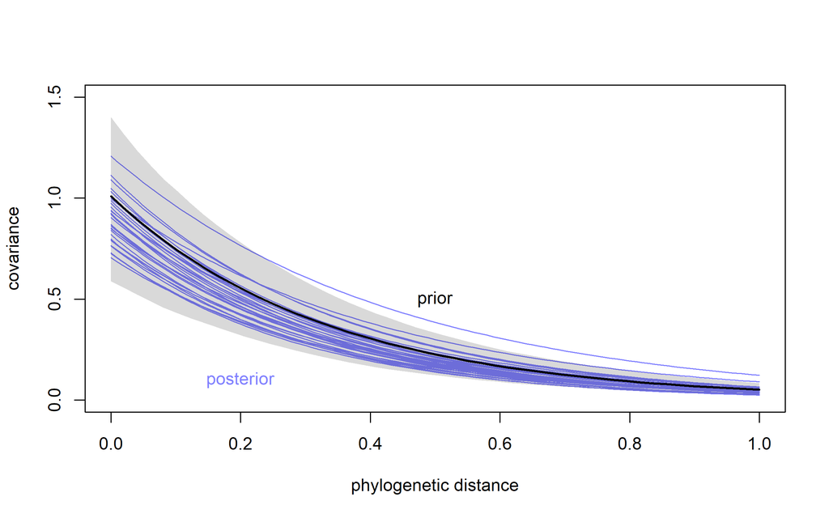

```r
post <- extract.samples(m5)

plot(NULL, xlim = c(0, max(dat_list$Dmat)), ylim = c(0, 1.5),
     xlab = "phylogenetic distance", ylab = "covariance")

# posterior
for(i in 1:30)
    curve(post$etasq[i] * exp(-post$rhosq[i]*x), add = TRUE, col = rangi2)

# prior mean and 89% interval
eta <- abs(rnorm(1e3, 1, 0.25))
rho <- abs(rnorm(1e3, 3, 0.25))
d_seq <- seq(from = 0, to = 1, length.out = 50)
K <- sapply(d_seq, function(x) eta*exp(-rho*x))

lines(d_seq, colMeans(K), lwd = 2)
shade(apply(K, 2, PI), d_seq)

text(0.5, 0.5, "prior")
text(0.2, 0.1, "posterior", col = rangi2)
```

The posterior is almost the same as the prior. This can also be seen in the `precis` output of the previous `precis`. So either the data was not enough or our initial prior happened to be very close to the posterior.

# Hard Questions

## 14H1

> Let’s revisit the Bangladesh fertility data, data(bangladesh), from the practice problems for Chapter 13. Fit a model with both varying intercepts by district_id and varying slopes of urban by district_id. You are still predicting use.contraception. Inspect the correlation between the intercepts and slopes. Can you interpret this correlation, in terms of what it tells you about the pattern of contraceptive use in the sample? It might help to plot the mean (or median) varying effect estimates for both the intercepts and slopes, by district. Then you can visualize the correlation and maybe more easily think through what it means to have a particular correlation. Plotting predicted proportion of women using contraception, with urban women on one axis and rural on the other, might also help.

```r
library(rethinking)
data("bangladesh")
d <- bangladesh
d$district_id <- as.integer(as.factor(d$district))
head(d)
```

```
##   woman district use.contraception living.children age.centered urban
## 1     1        1                 0               4      18.4400     1
## 2     2        1                 0               1      -5.5599     1
## 3     3        1                 0               3       1.4400     1
## 4     4        1                 0               4       8.4400     1
## 5     5        1                 0               1     -13.5590     1
## 6     6        1                 0               1     -11.5600     1
##   district_id
## 1           1
## 2           1
## 3           1
## 4           1
## 5           1
## 6           1
```

- `woman` : ID for each woman in the sample
- `district:` number for each district
- `use.contraception` - 0/1 indicator of contraceptive use
- `living.children` = num of living children
- `age` - centred age
- `urban` - 0/1 indicator of urban context

We will be fitting the following model:

$$\begin{align}
\text{use.contraceptive} &\sim \text{Binomial}(1, p_i) \\
\text{logit}(p_i) &= \alpha_{\text{district[i]}} + \beta_{\text{district[i]}} \operatorname{Urban} \\
\text{Adaptive Priors:}& \\
\begin{bmatrix}
\alpha_{\text{district[i]}} \\ \beta_{\text{district[i]}}
\end{bmatrix} &\sim \text{MVNormal}
\left(
\begin{bmatrix}
\alpha \\ \beta
\end{bmatrix} , S
\right) \\
S &= \begin{pmatrix}
\sigma_\alpha & 0 \\ 0 & \sigma_\beta
\end{pmatrix} R \begin{pmatrix}
\sigma_\alpha & 0 \\ 0 & \sigma_\beta
\end{pmatrix} \\
R &\sim \text{LKJcorr}(2) \\
\alpha &\sim \text{Normal}(0, 1.5) \\
\beta &\sim \text{Normal}(0, 1) \\
\sigma_\alpha, \sigma_\beta &\sim \text{Exponential}(1)
\end{align}$$

Nothing too different here. Let’s model the above:

```r
dat_list <- list(
    UC = d$use.contraception,
    urban = d$urban,
    age = d$age.centered,
    children = d$living.children,
    district = d$district_id
)

mh1 <- ulam(
    alist(
        UC ~ binomial(1, p),
        logit(p) <- a[district] + bU[district] * urban,

        c(a, bU)[district] ~ multi_normal(c(alpha, beta), Rho, sigma_district),
        alpha ~ normal(0, 1.5),
        beta ~ normal(0, 1),

        sigma_district ~ exponential(1),
        Rho ~ lkj_corr(2)
    ), data = dat_list, chains = 4, cores = 4
)
```

Let’s see the correlation between the intercept and slope:

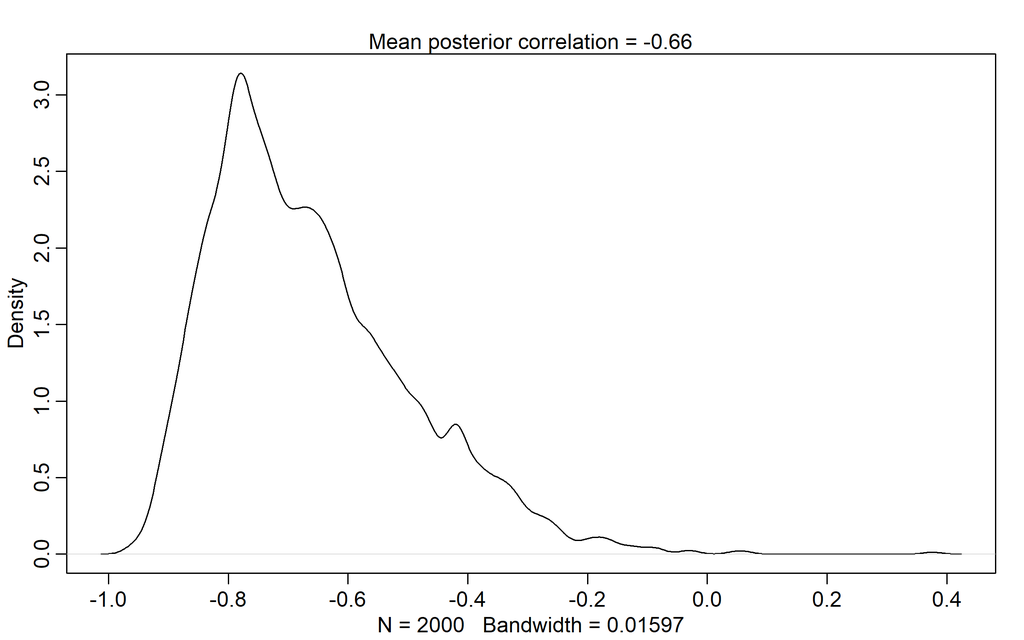

```r
post <- extract.samples(mh1)
dens(post$Rho[, 1, 2])
cor <- mean(post$Rho[, 1, 2])
mtext(sprintf("Mean posterior correlation = %.2f", round(cor, 2)))
```

We can also directly plot the intercepts and slopes from the posterior to see the negative correlation:

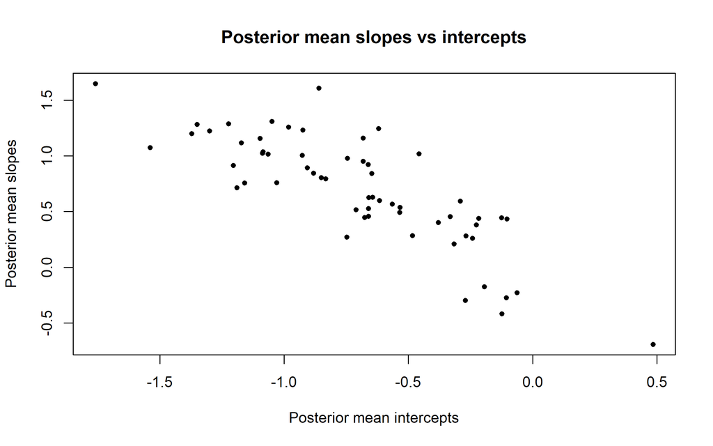

```r
plot(colMeans(post$a), colMeans(post$bU), pch = 20,
     xlab = "Posterior mean intercepts", ylab = "Posterior mean slopes",
     main = "Posterior mean slopes vs intercepts")
```

Let’s visualise at the varying intercepts and slopes by district:

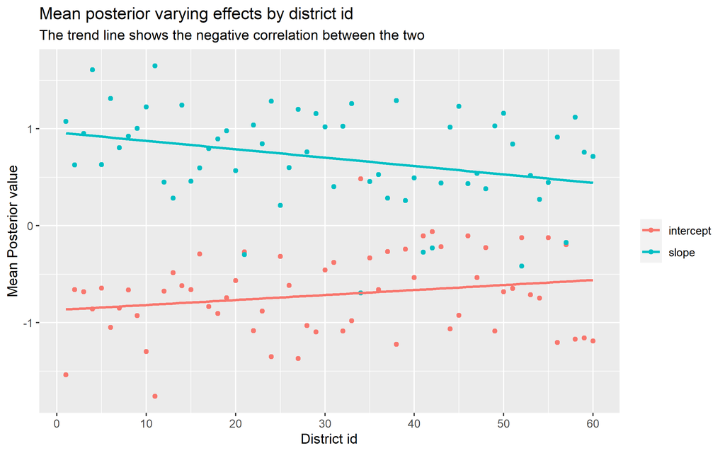

```r
alpha <- post$a
beta  <- post$bU
library(tidyr)
library(dplyr)

params <- purrr::imap_dfr(list(intercept = alpha, slope = beta), function(x, nm)

    pivot_longer(as.data.frame(x), cols = everything(),
                 names_prefix = "V", names_to = "district_id", names_transform = list(district_id = as.integer)) %>%
        mutate(parameter = nm)
)

params %>%
    group_by(district_id, parameter) %>%
    summarise(mean = mean(value), .groups = "drop") %>%
    ggplot(aes(x = district_id, y = mean, colour = parameter)) +
    geom_point() +
    # facet_wrap(~parameter) +
    scale_x_continuous(n.breaks = 10) +
    geom_smooth(method = "lm", se = FALSE) +
    labs(x = "District id",
         y = "Mean Posterior value",
         title = "Mean posterior varying effects by district id",
         subtitle = "The trend line shows the negative correlation between the two",
         colour = "")
```

I have plotted the mean posterior varying effects for each district and added a simple trend line for the two parameters. We can see the negative correlation between the slope and intercept varying effects.

Let’s take a look at the posterior predictions by the model:

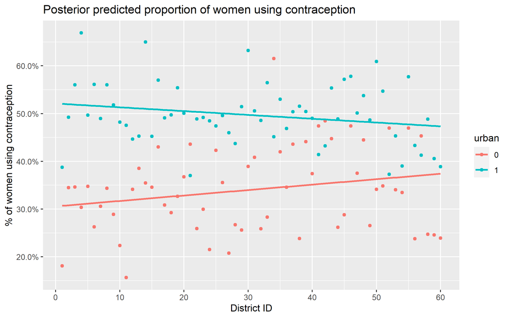

```r
test_data <- crossing(district = 1:60,
                      urban = 0L:1L)
preds <- link(mh1, data = test_data, post = post)

# create test data with districts from 1 to 60 and both urban = 0 and 1
crossing(district = 1:60, urban = 0L:1L) %>%
    nest(data = c(district, urban)) %>%

    # get predictions from model
    mutate(pred = purrr::map(data, ~link(mh1, data = ., post = post))) %>%

    # extract posterior means for each district-urban combination
    mutate(mean_prop = purrr::map(pred, colMeans)) %>%

    # formatting
    unnest(c(data, mean_prop)) %>%
    select(-pred) %>%
    mutate(urban = as.factor(urban)) %>%

    # plot the results
    ggplot(aes(x = district, y = mean_prop, colour = urban)) +
    geom_point() +

    # trend line
    geom_smooth(method = "lm", se = FALSE) +

    # formatting
    labs(x = "District ID",
         y = "% of women using contraception",
         title = "Posterior predicted proportion of women using contraception") +
    scale_y_continuous(labels = scales::percent) +
    scale_x_continuous(n.breaks = 10)
```

I have plotted the predicted proportion of women using contraception for each district while keeping both urban to 0 and 1 for each district (indicator of urban context). We can see that the higher district ids have a higher rate of women using contraception among the non-urbans and vice versa for the urbans, although the variation is high. A trend line has been plotted to ease these observations. The effect of `urban` also seems to be substantial, with a clear demarcation between their proportions.

## 14H2

> Now consider the predictor variables `age.centered` and `living.children`, also contained in `data(bangladesh)`. Suppose that age influences contraceptive use (changing attitudes) and number of children (older people have had more time to have kids). Number of children may also directly influence contraceptive use. Draw a DAG that reflects these hypothetical relationships. Then build models needed to evaluate the DAG. You will need at least two models. Retain district and urban, as in 14H1. What do you conclude about the causal influence of age and children?

Let’s draw the DAG implied in the question.

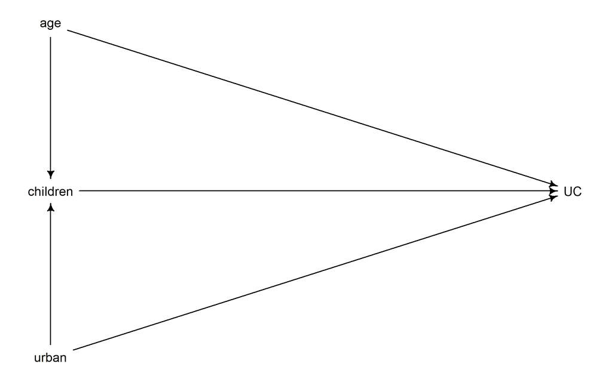

```r
library(dagitty)
women_dag <- dagitty("dag{
                     age      -> UC
                     age      -> children
                     children -> UC
                     urban    -> UC
                     urban    -> children
}")
coordinates(women_dag) <- list(
    x = c(age = 0, UC = 1, children = 0, urban = 0),
    y = c(age = 0, UC = 1, children = 1, urban = 2)
)
drawdag(women_dag)
```

I have also added `urban` in the DAG, since it might be a possible influence for the number of children (people have more children in rural areas compared to urban areas generally).

We want to find the effect of age and children on use of contraception.

Let’s use dagitty to find out which variables to condition on for each case:

```r
adjustmentSets(women_dag, exposure = "age", outcome = "UC")
```

```
##  {}
```

So for determining the influence of age, we don’t need to condition on anything (this is also apparent from the DAG, there are no backdoors into age). As mentioned in the question, we will retain `district` and `urban`. We will not be using varying effects for age.

```r
adjustmentSets(women_dag, exposure = "children", outcome = "UC")
```

```
## { age, urban }
```

The two models:

```r
mh2_age <- ulam(
    alist(
        UC ~ binomial(1, p),
        logit(p) <- a[district] + bU[district] * urban + bA*age,

        c(a, bU)[district] ~ multi_normal(c(alpha, beta), Rho, sigma_district),
        alpha ~ normal(0, 1.5),
        beta ~ normal(0, 1),
        bA   ~ normal(0, 1),

        sigma_district ~ exponential(1),
        Rho ~ lkj_corr(2)
    ), data = dat_list, chains = 4, cores = 4
)

mh2_child <- ulam(
    alist(
        UC ~ binomial(1, p),
        logit(p) <- a[district] + bU[district] * urban + bC*children,

        c(a, bU)[district] ~ multi_normal(c(alpha, beta), Rho, sigma_district),
        alpha ~ normal(0, 1.5),
        beta ~ normal(0, 1),
        bC   ~ normal(0, 1),

        sigma_district ~ exponential(1),
        Rho ~ lkj_corr(2)
    ), data = dat_list, chains = 4, cores = 4
)
```

Let’s look at the posterior for the two models:

```r
precis(mh2_age)
```

```
##               mean          sd         5.5%       94.5%    n_eff     Rhat4
## alpha -0.713601916 0.103300335 -0.886601825 -0.54800234 1632.806 1.0011521
## beta   0.708040127 0.173336229  0.441263798  0.99161999 1181.944 1.0027917
## bA     0.009160926 0.005464834  0.000563258  0.01784948 3177.854 0.9984234
```

```r
precis(mh2_child)
```

```
##             mean         sd       5.5%      94.5%    n_eff    Rhat4
## alpha -1.4288263 0.15350977 -1.6751111 -1.1854699 677.6901 1.003201
## beta   0.7285147 0.16942882  0.4717756  1.0057842 937.5943 1.007077
## bC     0.2636391 0.04011013  0.2011110  0.3278393 681.9462 1.002359
```

The coefficient for the effect of number of children is reliably positive, although small. Thus according to the model, with more children the use of contraception increases.

## 14H3

> Modify any models from 14H2 that contained that children variable and model the variable now as a monotonic ordered category, like education from the week we did ordered categories. Education in that example had 8 categories. Children here will have fewer (no one in the sample had 8 children). So modify the code appropriately. What do you conclude about the causal influence of each additional child on use of contraception?

Let us find the range of number of children in the dataset:

```r
range(dat_list$children)
```

```
## [1] 1 4
```

So we will have four levels. Let’s model children as an ordered categorical predictor.

```r
dat_list$alpha <- rep(2, 3)

mh3 <- ulam(
    alist(
        UC ~ binomial(1, p),
        # logit(p) <- a[[district]] + bU[[district]]*urban + bC*sum(delta_j[1:children]),
        logit(p) <- v[district, 1]  + v[district, 2]*urban + bC*sum(delta_j[1:children]),

        vector[2]: v[district] ~ multi_normal(v_mu, Rho, sigma_district),
        # c(a, bU)[district] ~ multi_normal(c(alpha, beta), Rho, sigma_district),

        vector[2]: v_mu ~ normal(0, 1),

        # alpha ~ normal(0, 1.5),
        # beta  ~ normal(0, 1),

        bC    ~ normal(0, 1),

        sigma_district[1] ~ exponential(1),
        sigma_district[2] ~ exponential(1),

        Rho ~ lkj_corr(2),

        vector[4]: delta_j <<- append_row(0, delta),
        simplex[3]: delta ~ dirichlet(alpha)

    ), data = dat_list, chains = 4, cores = 4
)
```

```r
precis(mh3, 2)
```

```
##                         mean         sd        5.5%      94.5%     n_eff
## v_mu[1]           -1.4235910 0.13922423 -1.65366792 -1.2060377  535.4721
## v_mu[2]            0.7440571 0.16397441  0.47862307  1.0098766  950.8708
## bC                 1.0075070 0.12760667  0.80223084  1.2097997  641.4458
## sigma_district[1]  0.5808545 0.09497251  0.43913847  0.7411065  638.6144
## sigma_district[2]  0.7613002 0.19780482  0.45542424  1.0812758  245.2527
## delta[1]           0.7964260 0.07990189  0.66342573  0.9149596 2850.2916
## delta[2]           0.1288243 0.07252533  0.03099342  0.2541114 2568.7797
## delta[3]           0.0747497 0.04686873  0.01526739  0.1617066 2856.2256
##                       Rhat4
## v_mu[1]           1.0053224
## v_mu[2]           1.0055142
## bC                1.0056334
## sigma_district[1] 1.0018035
## sigma_district[2] 1.0199243
## delta[1]          1.0007587
## delta[2]          1.0002724
## delta[3]          0.9991221
```

The coefficient for `living.children` `bC` is 1 and strictly positive. This is the maximum effect possible at children = 4. So we still have contraception use increasing with increasing number of living children. However, if we look at the `delta` parameters, we can see that the effect is not the same throughout. `delta[1]`, which is the effect on use of contraception from going from one living children to two, is the highest.

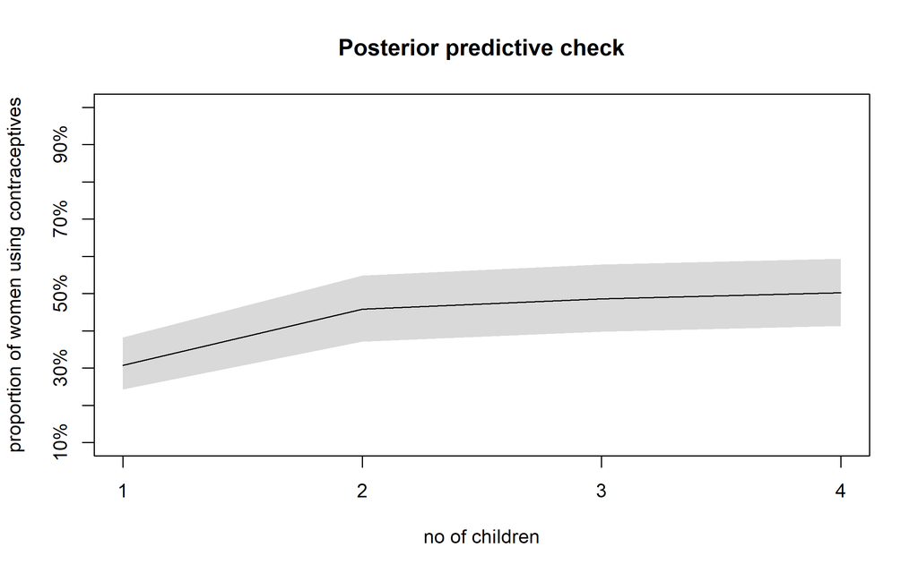

```r
post <- extract.samples(mh3)
delta <- post$delta
delta_mu <- apply(delta, 2, mean)
delta_PI <- apply(delta, 2, PI)

new_dat <- expand.grid(
    urban = 0,
    age   = 0,
    children = 1:4,
    district = 1
)

post$delta <- cbind(0, post$delta)

preds <- matrix(NA, nrow = 2000, ncol = 4)
for(i in 1:4){
    did <- 1
    urban <- 1
    children <- i

    for(j in 1:2000)
        preds[j, i] <- with(post,
                            inv_logit(v[j, did, 1] + v[j, did,2] * urban + bC[j] * sum(delta[j,1:children]))
        )
}

plot(NULL, xlim = c(1, 4), ylim = c(0, 1),
     xlab = "no of children", ylab = "proportion of women using contraceptives",
     main = "Posterior predictive check", xaxt = "n", yaxt = "n")
axis(1, at = 1:4)
axis(2, at = seq(0, 1, length.out = 10), labels = paste0(seq(10, 100, 10), "%"))
lines(1:4, colMeans(preds))
shade(apply(preds, 2, PI), 1:4)
```

Treating number of living children as an ordered categorical predictor leads to an increased association with use of contraceptives and we get deeper insights, that the effect is not constant for different number of children, but maximum at two children.

## 14H4

> Varying effects models are useful for modeling time series, as well as spatial clustering. In a time series, the observations cluster by entities that have continuity through time, such as individuals. Since observations within individuals are likely highly correlated, the multilevel structure can help quite a lot. You’ll use the data in data(Oxboys), which is 234 height measurements on 26 boys from an Oxford Boys Club (I think these were like youth athletic leagues?), at 9 different ages (centered and standardized) per boy. You’ll be interested in predicting height, using age, clustered by `Subject` (individual boy). Fit a model with varying intercepts and slopes (on age), clustered by Subject. Present and interpret the parameter estimates. Which varying effect contributes more variation to the heights, the intercept or the slope?

```r
library(rethinking)
data("Oxboys")
d <- Oxboys
str(d)
```

```
## 'data.frame':    234 obs. of  4 variables:
##  $ Subject : int  1 1 1 1 1 1 1 1 1 2 ...
##  $ age     : num  -1 -0.7479 -0.463 -0.1643 -0.0027 ...
##  $ height  : num  140 143 145 147 148 ...
##  $ Occasion: int  1 2 3 4 5 6 7 8 9 1 ...
```

We will create the following model:

$$\begin{align}
\operatorname{Height}_i &\sim \text{Normal}(\mu_i, \sigma) \\
\mu_i &= \alpha_{\text{subject[i]}} + \beta_{\text{subject[i]}} \operatorname{Age} \\
\text{Varying effects:}& \\
\begin{bmatrix}
\alpha_{\text{subject[i]}} \\ \beta_{\text{subject[i]}}
\end{bmatrix} &\sim \text{MVNormal}
\left(
\begin{bmatrix}
\alpha \\ \beta
\end{bmatrix} , S
\right) \\
S &= \begin{pmatrix}
\sigma_\alpha & 0 \\ 0 & \sigma_\beta
\end{pmatrix} R \begin{pmatrix}
\sigma_\alpha & 0 \\ 0 & \sigma_\beta
\end{pmatrix} \\
\text{Priors:}& \\
\alpha, \beta &\sim \text{Normal}(0, 1) \\
\sigma, \sigma_\alpha, \sigma_\beta &\sim \text{Exponential}(1) \\
R &\sim \text{LKJCorr}(2)
\end{align}$$

Modelling this:

```r
dat_list <- list(
    height = standardize(d$height),
    age    = d$age,
    subject = d$Subject
)

mh4 <- ulam(
    alist(
        height ~ normal(mu, sigma),
        mu <- a[subject] + bA[subject]*age,

        c(a, bA)[subject] ~ multi_normal(c(a_bar, b_bar), Rho, sigma_subject),

        a_bar         ~ normal(0, 1),
        b_bar         ~ normal(0, 1),
        Rho           ~ lkj_corr(2),
        sigma         ~ exponential(1),
        sigma_subject ~ exponential(1)

    ), data = dat_list, chains = 4, cores = 4
)
```

Let’s look at the posterior means:

```r
precis(mh4)
```

```
##              mean          sd        5.5%      94.5%    n_eff     Rhat4
## a_bar -0.01294034 0.179385608 -0.30069716 0.27319737 2252.595 0.9994288
## b_bar  0.71561390 0.039097060  0.65411174 0.77736024 2051.995 0.9991905
## sigma  0.07313511 0.003801833  0.06736754 0.07954882 2110.088 0.9990639
```

We standardised height for modelling, so mean of intercept comes out as zero as expected. The mean value of the slope (for age) is positive, implying age increases with height (no surprises there!). Let’s look at the standard deviations of the two varying effects:

```r
precis(mh4, 2, pars = c("sigma_subject"))
```

```
##                       mean         sd      5.5%     94.5%    n_eff     Rhat4
## sigma_subject[1] 0.9064391 0.12335256 0.7287740 1.1120788 2354.533 1.0002239
## sigma_subject[2] 0.1897471 0.02850249 0.1499749 0.2406863 2797.323 0.9997246
```

There’s much larger variation in the intercepts than the slopes. (`sigma_subject[1]` denotes variation for intercept).

## 14H5

> Now consider the correlation between the varying intercepts and slopes. Can you explain its value? How would this estimated correlation influence your predictions about a new sample of boys?

```r
precis(mh4, 3, pars = "Rho")
```

```
##               mean           sd      5.5%     94.5%    n_eff    Rhat4
## Rho[1,1] 1.0000000 0.000000e+00 1.0000000 1.0000000      NaN      NaN
## Rho[1,2] 0.5658196 1.336391e-01 0.3318238 0.7507716 2551.827 1.000432
## Rho[2,1] 0.5658196 1.336391e-01 0.3318238 0.7507716 2551.827 1.000432
## Rho[2,2] 1.0000000 7.428743e-17 1.0000000 1.0000000 1549.828 0.997998
```

The correlation is positive and moderately strong. Let’s visualise the full posterior of the correlation.

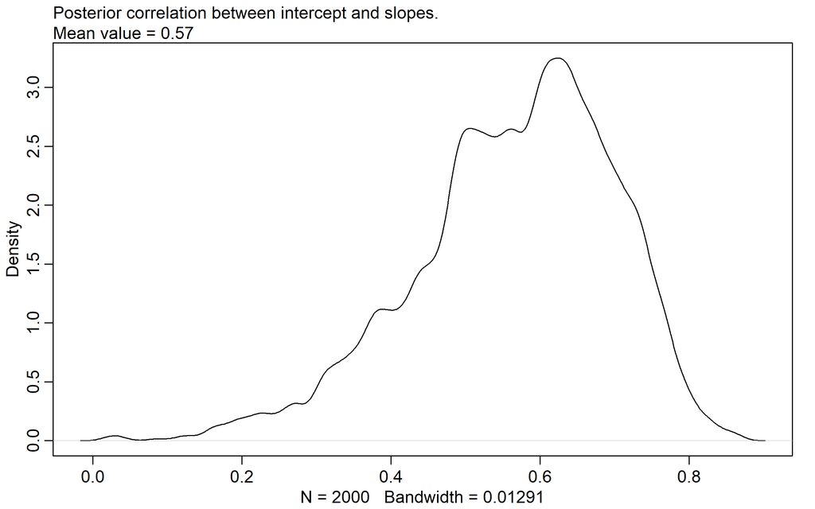

```r
post <- extract.samples(mh4)
dens(post$Rho[, 1, 2])
mtext(sprintf("Posterior correlation between intercept and slopes. \nMean value = %.2f", mean(post$Rho[, 1, 2])), adj = 0)
```

The correlation is positive and moderately strong. This implies that the slope increases with increasing intercept. In practical terms, taller boys get taller more quickly with age.

## 14H6

> Use mvrnorm (in library(MASS)) or rmvnorm (in library(mvtnorm)) to simulate a new sample of boys, based upon the posterior mean values of the parameters. That is, try to simulate varying intercepts and slopes, using the relevant parameter estimates, and then plot the predicted trends of height on age, one trend for each simulated boy you produce. A sample of 10 simulated boys is plenty, to illustrate the lesson. You can ignore uncertainty in the posterior, just to make the problem a little easier. But if you want to include the uncertainty about the parameters, go for it. Note that you can construct an arbitrary variance-covariance matrix to pass to either mvrnorm or rmvnorm with something like:

```r
S <- matrix(c (sa^2, sa*sb*rho, sa*sb*rho, sb^2), nrow = 2)
```

> where sa is the standard deviation of the first variable, sb is the standard deviation of the second variable, and rho is the correlation between them.

Let’s extract samples from posterior:

```r
post <- extract.samples(mh4)

sigma_int   <- mean(post$sigma_subject[,1])
sigma_slope <- mean(post$sigma_subject[,2])
rho         <- mean(post$Rho[, 1, 2])

S <- matrix( c (sigma_int^2,
                sigma_int * sigma_slope*rho,
                sigma_int * sigma_slope*rho,
                sigma_slope^2), nrow = 2)
mu <- c(mean(post$a_bar), mean(post$b_bar))
```

Let’s pull some intercepts and slopes:

```r
set.seed(213)
sim_samples <- MASS::mvrnorm(n = 10, mu = mu, Sigma = S)
```

Let’s predict height using these:

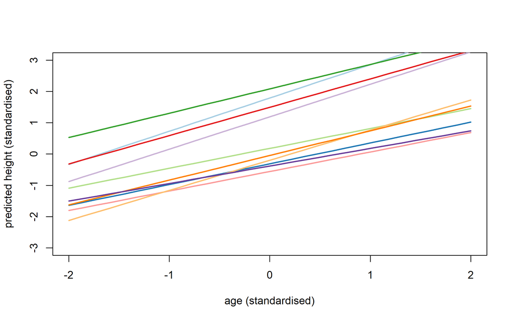

```r
age_seq <- seq(-2, 2, length.out = 30)

# create empty matrix of predictions,
# rows are samples
# columns are predicted values for increasing age
preds <- matrix(NA, nrow = 10, ncol = 30)

# compute predictions for each person
for(i in 1:10){
    preds[i, ] <- t(cbind(1, age_seq) %*% sim_samples[i,]) # this is just Y_hat = XB
}

cols <- RColorBrewer::brewer.pal(n = 10, "Paired")
plot(NULL, xlim = c(-2, 2), ylim = c(-3, 3),
     xlab = "age (standardised)", ylab = "predicted height (standardised)")
for(i in 1:10)
    lines(age_seq, preds[i, ], col = cols[i], lwd = 2)
```